# Biofilm Formation of Gardnerella Strains

Hanna Berman

May 25, 2026

**Purpose:** To measure the capacity for each strain to grow as a biofilm

**Protocol:**

- Streak out strains on BHI Plates and incubate at 37$^\circ$C anaerobically for 48 hours
- Pick two colonies of each strain and inoculate each colony into 1 mL NYC-III media and incubate for 24 (protocols 1 and 2) or 48 hours (protocol 3) at 37$^\circ$C anaerobically
- Measure OD<sub>600</sub> and back-dilute cultures 1:100 in 1 mL fresh NYC-III media and incubate for 24 (protocols 1 and 2) or 48 hours (protocol 3) at 37$^\circ$C anaerobically
- Measure OD<sub>600</sub> and back dilute cultures 1:10 in fresh NYC-III media and incubate for 4 (protocol 1), 7 (protocol 2) or 15 hours (protocol 3) at 37$^\circ$C anaerobically
- Measure OD<sub>600</sub> and dilute cultures to OD<sub>600</sub>=0.01 in NYC-III media in and seed into two sets of tissue-culture treated sterile culture plates. Incubate for 24 (protocols 1 and 2) or 48 (protocol 3) hours at 37$^\circ$C anaerobically.
- For Percent OD plate:
  - Remove supernatant and measure OD<sub>600</sub> for optical density of planktonic growth
  - Resuspend biofilms in 200uL fresh NYC-III media per well and measure OD<sub>600</sub>
  - Calculate percent growth as biofilm by $OD_{600(biofilm)}~/(OD_{600(biofilm)}+OD_{600(planktonic)})$
- For safranin plate
  - Remove supernatant and measure OD<sub>600</sub> of planktonic growth
  - Let biofilms dry overnight
  - Stain biofilms with safranin stain: pour stain over plates, incubate for two minutes then rinse with diH<sub>2</sub>O. Let dry for two hours or overnight
  - Resuspend stained biofilms in 33% acetic acid and measure OD<sub>450</sub>

```r
library(tidyverse)
library(openxlsx)
library(broom)
library(rstatix)
library(ggbeeswarm)
library(formattable)
library(ggpubr)
library(cowplot)
library(corrplot)
library(ggpubr)
library(grid)
library(gridGraphics)

`%!in%` <- negate(`%in%`)
```

# Formatting and set up

Short cuts:

```r
strains <- c("14018", "315-A", "C0011E4", "JCP7275", "C0084H9", "JCP8108", "JCP8017B", "C0040C2" , "UM35",  "JCP8066", "C0093B3", "AMD", "C0096A1", "C0102A2",  "UM224", "Gv5-1", "C0179B4", "C0056B5", "Gv101", "C0100B2", "C0101A1", "CMW7778B")

strains0 <- c("14018", "315-A", "C0011E4", "JCP7275", "C0084H9", "JCP8108", "JCP8017B", "C0040C2" , "UM35",  "JCP8066", "C0093B3", "AMD", "C0096A1", "C0102A2",  "UM224", "5-1", "C0179B4", "C0056B5", "101", "C0100B2", "C0101A1", "CMW7778B")

species <- c("Gardnerella vaginalis", "Gardnerella lacydonensis", "Gardnerella pickettii", "Gardnerella piotii", "Gardnerella leopoldii", "Gardnerella swidsinskii", "Gardnerella sp. 7", "Gardnerella greenwoodii", "Gardnerella sp. 10", "Gardnerella sp. 11", "Gardnerella sp. 12")
speciesAbbrevs <- c("G. vag.", "G. lac.", "G. pic.", "G. pio.", "G. leo.", "G. swi.", "7", "G. gre.", "10", "11", "12")

figureOut <- "../../experiments_figures"
suppTableOut <- paste0("../../experiments_figures/", Sys.Date(), "_supplementary_posthoc_tables.xlsx")
formattedPhenDataOut <- "../formatted_phenotype_data"
```

Import data and add updated species names

```r
midlog_raw_data <- read_csv("./data/biofilm_midlog_raw_data.csv")  %>%
  mutate(Species=case_when(Species=="Gardnerella sp. 2"~"Gardnerella lacydonensis",
                           Species=="Gardnerella sp. 3"~"Gardnerella pickettii",
                           Species=="Gardnerella sp. 8"~"Gardnerella greenwoodii",
                           Species %!in% c("Gardnerella sp. 2", "Gardnerella sp. 3", "Gardnerella sp. 8")~Species))
rawPlanktonicODs <- read_csv("./data/planktonic_od_raw_data.csv")  %>%
  mutate(Species=case_when(Species=="Gardnerella sp. 2"~"Gardnerella lacydonensis",
                           Species=="Gardnerella sp. 3"~"Gardnerella pickettii",
                           Species=="Gardnerella sp. 8"~"Gardnerella greenwoodii",
                           Species %!in% c("Gardnerella sp. 2", "Gardnerella sp. 3", "Gardnerella sp. 8")~Species))
rawBiofilmODs <- read_csv("./data/biofilm_od_raw_data.csv")  %>%
  mutate(Species=case_when(Species=="Gardnerella sp. 2"~"Gardnerella lacydonensis",
                           Species=="Gardnerella sp. 3"~"Gardnerella pickettii",
                           Species=="Gardnerella sp. 8"~"Gardnerella greenwoodii",
                           Species %!in% c("Gardnerella sp. 2", "Gardnerella sp. 3", "Gardnerella sp. 8")~Species))
rawSafPlanktonicODs <- read_csv("./data/safranin_planktonic_raw_data.csv")  %>%
  mutate(Species=case_when(Species=="Gardnerella sp. 2"~"Gardnerella lacydonensis",
                           Species=="Gardnerella sp. 3"~"Gardnerella pickettii",
                           Species=="Gardnerella sp. 8"~"Gardnerella greenwoodii",
                           Species %!in% c("Gardnerella sp. 2", "Gardnerella sp. 3", "Gardnerella sp. 8")~Species))
rawSafBiofilmODs <- read_csv("./data/safranin_biofilm_raw_data.csv")  %>%
  mutate(Species=case_when(Species=="Gardnerella sp. 2"~"Gardnerella lacydonensis",
                           Species=="Gardnerella sp. 3"~"Gardnerella pickettii",
                           Species=="Gardnerella sp. 8"~"Gardnerella greenwoodii",
                           Species %!in% c("Gardnerella sp. 2", "Gardnerella sp. 3", "Gardnerella sp. 8")~Species))
```

Plot settings

```r
theme_set(theme_bw()+
          theme(panel.grid = element_blank()))

speciesColor <- scale_color_manual(values=c("#CC79A7", "#D55E00", "#56B4E9", "#0072B2", "#E69F00", "#009E73",
                                                 "darkgreen", "gold3", "darkred", "darkblue",
                                                 "mediumpurple4"))

speciesFill <- scale_fill_manual(values=c("#CC79A7", "#D55E00", "#56B4E9", "#0072B2", "#E69F00", "#009E73",
                                                 "darkgreen", "gold3", "darkred", "darkblue",
                                                 "mediumpurple4"))
```

# Set up growth

Propagate twice and then incubate to mid log. 1:10 Dilution for mid Log: Protocol 1: 4 hour incubation Protocol 2: 7 hour incubation Protocol 3: 15 hour incubation ## Clean data

```r
setupDF <- midlog_raw_data %>%
  group_by(Number, BioRep, Species, Strain, Batch, Step) %>%
  mutate(OD=OD-mean(.$OD[.$Number=="Blank"]),
                      OD=case_when(OD>0~OD,
                      OD<=0~0)) %>%
  filter(Number!="Blank") %>%
  mutate(Step=factor(Step, levels=c("Overnight 1", "Overnight 2", "Mid Log"))) %>%
  mutate(Strain=factor(Strain, levels=strains),
         Species=factor(Species, levels=species),
         Sample=paste(Strain, Batch, BioRep, sep="."),
         BatchNum=str_extract(Batch, "(?<=[A|B])[0-9]"),
         BatchRep=paste(BatchNum, BioRep, sep="."),
         StrainN=as.numeric(Strain),
         rectFill=case_when(StrainN %% 2 == 0 ~ "A",
                           StrainN %% 2 != 0 ~ "B")) %>%
  ungroup %>%
  with_groups(c("Sample", "Number", "BioRep", "Batch", "BatchNum", "BatchRep", "StrainN", "rectFill", "Species", "Strain", "Protocol",  "Step"), summarize, ODm=mean(OD), ODsd=sd(OD))
```

Assess mid log growth for removing poor growers with OD<sub>600</sub> < 0.05

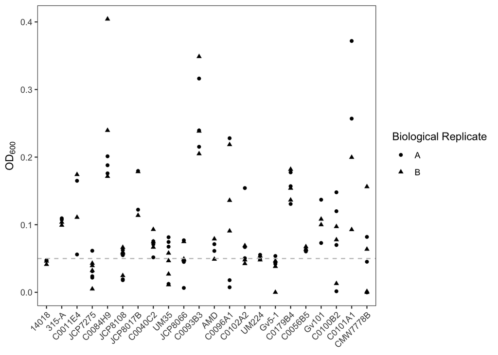

```r
setupDF %>%
  filter(Step=="Mid Log") %>%
  ggplot(aes(x=Strain, y=ODm)) +
  geom_point(aes(shape=BioRep)) +
  geom_hline(aes(yintercept=0.05), linetype=2, color="gray") +
  theme(axis.text.x = element_text(angle=45, hjust=1)) +
  labs(x=NULL, y=bquote(OD[600]), shape="Biological Replicate")
```

Create quality filter for OD<sub>600</sub> > 0.05

```r
midLogFail <- setupDF %>%
  filter(Step=="Mid Log",
         ODm < 0.05) %>%
  .$Sample

midLogFail
```

```
##  [1] "14018.1A1.A"    "14018.1A1.B"    "14018.1A2.A"    "14018.1A2.B"
##  [5] "AMD.2A1.B"      "C0096A1.2A2.A"  "C0096A1.2A3.A"  "C0100B2.1AB3.A"
##  [9] "C0100B2.1AB3.B" "C0102A2.1A1.B"  "C0102A2.1A2.B"  "CMW7778B.2A1.A"
## [13] "CMW7778B.2A1.B" "CMW7778B.2A2.A" "CMW7778B.2A2.B" "CMW7778B.2A3.A"
## [17] "Gv5-1.1AB3.A"   "Gv5-1.1AB3.B"   "Gv5-1.1B1.A"    "Gv5-1.1B1.B"
## [21] "Gv5-1.1B2.B"    "JCP7275.1AB3.A" "JCP7275.1AB3.B" "JCP7275.1AB4.B"
## [25] "JCP7275.1B1.A"  "JCP7275.1B1.B"  "JCP7275.1B2.A"  "JCP7275.1B2.B"
## [29] "JCP8066.1A2.A"  "JCP8066.1A2.B"  "JCP8066.1AB3.A" "JCP8066.1AB3.B"
## [33] "JCP8108.1B1.A"  "JCP8108.1B2.A"  "JCP8108.1B2.B"  "UM224.1A1.A"
## [37] "UM224.1A2.B"    "UM35.3A1.B"     "UM35.3A2.A"     "UM35.3A2.B"
## [41] "UM35.3A3.B"
```

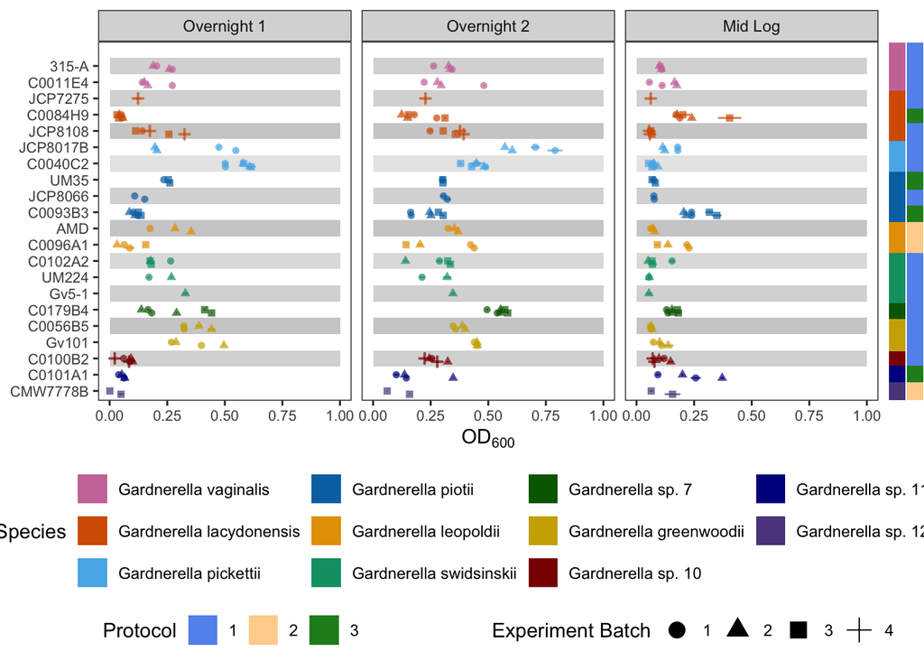

```r
overnightPlot <- setupDF %>%
  filter(Sample %!in% midLogFail) %>%
  ggplot(aes(x=Strain, y=ODm)) +
  geom_point(aes(shape=BatchNum), alpha=0) +
  geom_rect(aes(xmin=StrainN-.5, xmax=StrainN+.5, ymin = 0, ymax = 1, fill=rectFill), alpha = 0.2, show.legend = FALSE) +
  geom_pointrange(aes(ymin=(ODm-ODsd), ymax=(ODm+ODsd), shape=BatchNum, color=Species), position = position_quasirandom(), size=0.3, alpha=0.7, show.legend = FALSE) +
  speciesColor +
  scale_fill_manual(values=c("white", "gray"), labels=c("A","B")) +
  ylim(0,1) +
  facet_grid(.~Step) +
  coord_flip() +
  scale_x_discrete(limits=rev) +
  theme(axis.text.x = element_text(size=8),
        axis.text.y = element_text(size=8),
        axis.title = element_text(size=11),
        panel.grid = element_blank(),
        legend.position = "none") +
  labs(x=NULL, y=bquote(OD[600]), shape="Experiment Batch")

#annotation bars
protocolBar <- setupDF %>%
  select(Strain, Species, Protocol) %>%
  mutate(Protocol=as.character(Protocol)) %>%
  unique %>%
  ggplot() +
    geom_bar(aes(x=Strain, y=2, fill=Protocol), stat="identity", width = 1.1) +
    scale_x_discrete(limits=rev) +
    scale_fill_manual(values=c("cornflowerblue", "burlywood1", "forestgreen")) +
    coord_flip() +
    theme_void() +
    theme(legend.position = "none")

speciesBar <- setupDF %>%
  select(Strain, Species, Protocol) %>%
  unique %>%
  ggplot() +
    geom_bar(aes(x=Strain, y=1, fill=Species), stat="identity", width=1.1) +
    scale_x_discrete(limits=rev) +
    speciesFill +
    coord_flip() +
    theme_void() +
    theme(legend.position = "none")

#Legends
protocol_legend <- ggpubr::get_legend(protocolBar +
    guides(color=guide_legend(ncol = 1)) +
    theme(legend.position = "bottom",
          legend.direction = "horizontal"))

species_legend <- ggpubr::get_legend(speciesBar +
    guides(color=guide_legend(ncol = 1)) +
    theme(legend.position = "bottom",
          legend.direction = "horizontal"))

experiment_legend <- ggpubr::get_legend(
  overnightPlot +
  guides(shape=guide_legend(nrow = 1, override.aes = list(alpha=1, size=4))) +
  theme(legend.position = "bottom"))


a <- plot_grid(overnightPlot, speciesBar, protocolBar, nrow = 1, align = "h", axis = "bt", rel_widths = c(1, 0.02, 0.02))
b <- plot_grid(a, as_ggplot(species_legend), nrow=2, rel_heights = c(1, 0.3))
c <- plot_grid(as_ggplot(protocol_legend), as_ggplot(experiment_legend), nrow=1)
plot_grid(b, c, ncol=1, nrow=2, rel_heights = c(1, 0.1))
```

# Percent Biofilm

## Calculate percent OD

```r
planktonicODs <- rawPlanktonicODs %>%
  group_by(Batch) %>%
  mutate(planktonicOD=OD-mean(.$OD[.$Number=="Blank"]),
         planktonicOD=case_when(planktonicOD>0~planktonicOD,
                                planktonicOD<=0~0)) %>%
  filter(Number!="Blank") %>%
  select(-OD, -Measure) %>%
  ungroup

biofilmODs <- rawBiofilmODs %>%
  group_by(Batch) %>%
  mutate(biofilmOD=OD-mean(.$OD[.$Number=="Blank"]),
         biofilmOD=case_when(biofilmOD>0~biofilmOD,
                             biofilmOD<=0~0)) %>%
  filter(Number!="Blank") %>%
  select(-OD, -Measure) %>%
  ungroup

percentOD <- planktonicODs %>%
  left_join(biofilmODs) %>%
  mutate(Sample=paste(Strain, Batch, BioRep, sep=".")) %>%
  filter(Sample %!in% midLogFail) %>% # quality filter for poor growth at mid log phase
  mutate(edgeWell=str_detect(well, pattern="[A|H]"),
         edgeWell=factor(edgeWell, levels=c(TRUE, FALSE)),
         innerWell=str_detect(well, pattern="[D|E]"),
         innerWell=factor(innerWell, levels=c(TRUE, FALSE)),
         topWell=str_detect(well, pattern="A"),
         topWell=factor(topWell, levels=c(TRUE, FALSE)))

head(percentOD)
```

```
## # A tibble: 6 × 13
##   well  Number BioRep Strain  Species      Protocol Batch planktonicOD biofilmOD
##   <chr> <chr>  <chr>  <chr>   <chr>           <dbl> <chr>        <dbl>     <dbl>
## 1 A2    1      A      C0011E4 Gardnerella…        1 1A1         0.196     0.0663
## 2 B2    1      A      C0011E4 Gardnerella…        1 1A1         0.193     0.0773
## 3 C2    1      A      C0011E4 Gardnerella…        1 1A1         0.172     0.0833
## 4 D2    1      A      C0011E4 Gardnerella…        1 1A1         0.138     0.0913
## 5 E2    1      B      C0011E4 Gardnerella…        1 1A1         0.0895    0.152
## 6 F2    1      B      C0011E4 Gardnerella…        1 1A1         0.0845    0.221
## # ℹ 4 more variables: Sample <chr>, edgeWell <fct>, innerWell <fct>,
## #   topWell <fct>
```

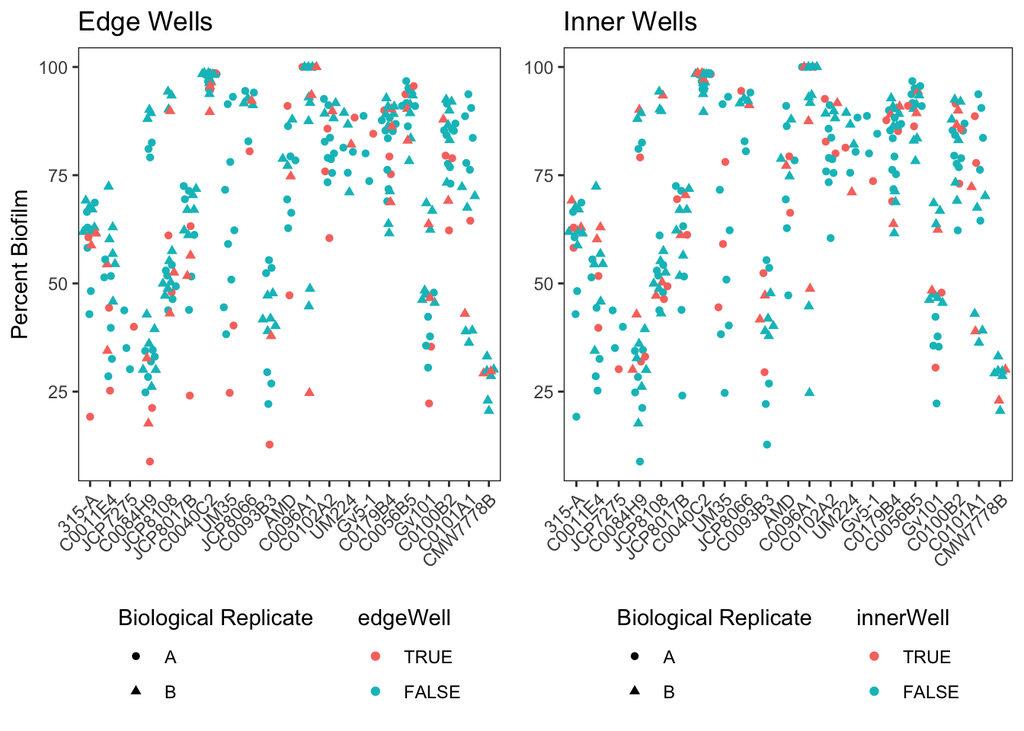

```r
edgeWellPlot <- percentOD %>%
  mutate(percentBiofilm=(biofilmOD/(biofilmOD+planktonicOD))*100,
         Strain=factor(Strain, levels = strains),
         Species=factor(Species, levels = species)) %>%
  ggplot(aes(x=Strain, y=percentBiofilm, shape=BioRep, color=edgeWell)) +
  geom_quasirandom() +
  theme(axis.text.x = element_text(angle=45, hjust=1),
        legend.position = "bottom",
        legend.direction = "vertical") +
  labs(x=NULL, y="Percent Biofilm", shape="Biological Replicate", title="Edge Wells")

innerWellPlot <- percentOD %>%
  mutate(percentBiofilm=(biofilmOD/(biofilmOD+planktonicOD))*100,
         Strain=factor(Strain, levels = strains),
         Species=factor(Species, levels = species)) %>%
  ggplot(aes(x=Strain, y=percentBiofilm, shape=BioRep, color=innerWell)) +
  geom_quasirandom() +
  theme(axis.text.x = element_text(angle=45, hjust=1),
        legend.position = "bottom",
        legend.direction = "vertical") +
  labs(x=NULL, y=NULL, shape="Biological Replicate", title="Inner Wells")

plot_grid(edgeWellPlot, innerWellPlot, nrow=1)
```

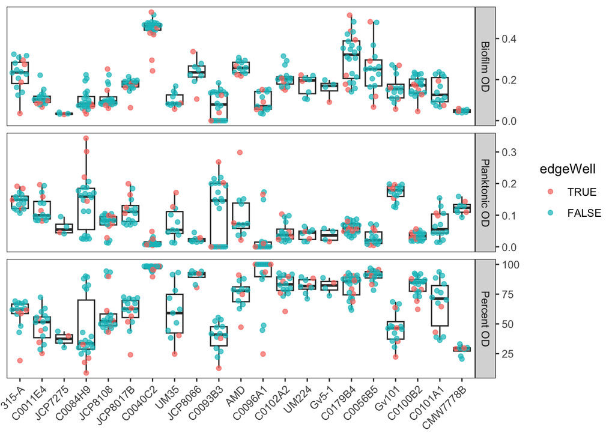

```r
percentODDF0 <- percentOD %>%
  mutate(percentBiofilm=(biofilmOD/(biofilmOD+planktonicOD))*100,
         Strain=factor(Strain, levels = strains),
         Species=factor(Species, levels = species),
         Protocol=as.character(Protocol),
         BatchRep=paste(Batch, BioRep, sep=".")) %>%
  gather("measure", "value", c(planktonicOD, biofilmOD, percentBiofilm)) %>%
  mutate(measure=factor(measure, levels=c("biofilmOD", "planktonicOD", "percentBiofilm"), labels=c("Biofilm OD", "Planktonic OD", "Percent OD")),
         BatchNum=str_extract(Batch, "(?<=[A|B])[0-9]"),
         BatchRep=paste(BatchNum, BioRep, sep="."))

percentODDF0 %>%
  ggplot(aes(x=Strain, y=value)) +
    geom_boxplot(alpha=0) +
    geom_quasirandom(aes(color=edgeWell), alpha=0.7) +
    scale_y_continuous(position = "right") +
    facet_grid(measure~., scales="free") +
    theme(axis.text.x = element_text(angle=45, hjust=1)) +
    labs(x=NULL, y=NULL, shape="Biological Replicate")
```

Remove Edge Wells

```r
naSamples <- percentODDF0 %>%
  filter(edgeWell==FALSE) %>%
  spread(measure, value) %>%
  filter(is.na(`Percent OD`)) %>%
  .$Sample %>%
  unique

naSamples
```

```
## [1] "C0093B3.3A2.A" "C0093B3.3A2.B"
```

```r
percentODDF <- percentODDF0 %>%
  filter(edgeWell==FALSE, # remove samples
         Sample %!in% naSamples) %>% # remove samples with no growth
  mutate(method="Percent OD")
```

### Isolates with extra samples

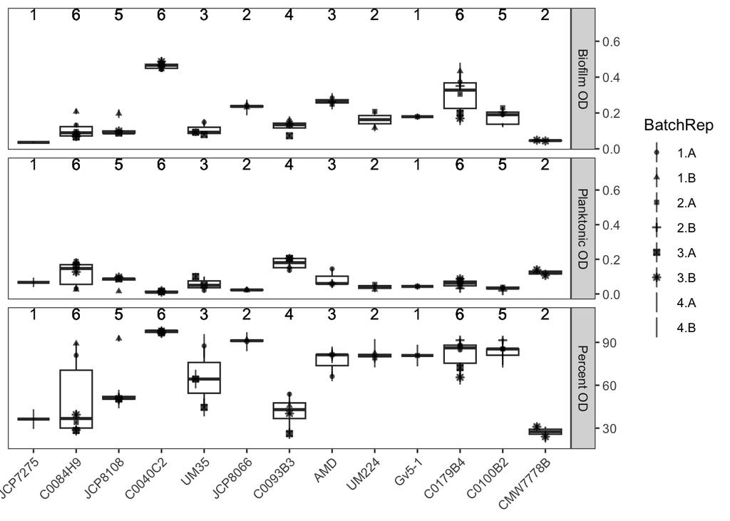

```r
non4StrainsPOD <- percentODDF0 %>%
 mutate(Sample=paste(Number, Sample, sep=".")) %>%
 with_groups(Strain, summarize, n=n_distinct(Sample)) %>%
 filter(n!=4) %>%
 .$Strain

percentODDF %>%
  filter(Strain %in% non4StrainsPOD) %>%
  mutate(Sample=paste(Number, Sample, sep=".")) %>%
  with_groups(Strain, mutate, n=n_distinct(Sample)) %>%
  with_groups(c("Number", "Strain", "Species", "Protocol", "Batch", "method", "Sample", "BatchRep", "measure", "BatchNum", "n"), summarize, valueM=mean(value), valueSD=sd(value)) %>%
  mutate(labelYpos=case_when(measure=="Biofilm OD"~0.75,
                             measure=="Planktonic OD"~0.75,
                             measure=="Percent OD"~110)) %>%
  ggplot() +
  geom_boxplot(aes(x=Strain, y=valueM), alpha=0) +
  geom_pointrange(aes(x=Strain, y=valueM, ymin=valueM-valueSD, ymax=valueM+valueSD, shape=BatchRep), alpha=0.7, size=0.25, position=position_quasirandom()) +
  geom_text(aes(x=Strain, y=labelYpos, label=n)) +
  scale_y_continuous(position = "right") +
  facet_grid(measure~., scales="free") +
  theme(axis.text.x = element_text(angle=45, hjust=1)) +
  labs(x=NULL, y=NULL)
```

## Plot

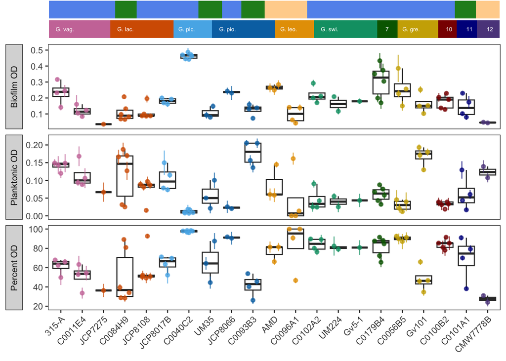

```r
## annotation portions of plot
#protocol bar
protocolBar0 <- percentODDF %>%
  select(Strain, Species, Protocol) %>%
  unique %>%
  ggplot() +
    geom_bar(aes(x=Strain, y=2, fill=Protocol), stat="identity", width = 1.1) +
    scale_fill_manual(values=c("cornflowerblue", "burlywood1", "forestgreen")) +
    theme_void() +
    theme(legend.position = "none")

# species bar
# speciesBar0 <- percentODDF %>%
#   select(Strain, Species, Protocol) %>%
#   unique %>%
#   ggplot() +
#     geom_bar(aes(x=Strain, y=1, fill=Species), stat="identity", width=1.1) +
#     speciesFill +
#     theme_void() +
#     theme(legend.position = "none")

speciesBar0 <- setupDF %>%
  select(Strain, Species, Protocol) %>%
  unique %>%
  mutate(Strain=factor(Strain, levels = strains),
         Species=factor(Species, levels = species),
         SpeciesLab=factor(Species, levels=species, labels=speciesAbbrevs)) %>%
  with_groups(Species, mutate, num=rank(Strain)) %>%
  mutate(SpeciesLab=case_when(num==1~SpeciesLab,
                              num!=1~"")) %>%
  ggplot() +
    geom_bar(aes(x=Strain, y=1, fill=Species), stat="identity", width=1.1) +
    geom_text(aes(x=Strain, y=0.5, label=SpeciesLab), color="white", hjust = 0.25, size=2) +
    speciesFill +
    theme_void() +
    theme(legend.position = "none")

percentODPlot <- percentODDF %>%
  with_groups(c("Number", "Strain", "Species", "Protocol", "Batch", "method", "Sample", "BatchRep", "measure", "BatchNum"), summarize, valueM=mean(value), valueSD=sd(value)) %>%
  ggplot() +
  geom_boxplot(aes(x=Strain, y=valueM), alpha=0) +
  geom_pointrange(aes(x=Strain, y=valueM, ymin=valueM-valueSD, ymax=valueM+valueSD, color=Species), alpha=0.7, size=0.25, position=position_quasirandom()) +
  speciesColor +
  facet_grid(measure~., scales="free", switch = "y") +
  theme(axis.text.x = element_text(angle=45, hjust=1),
        legend.position = "none",
        strip.placement = "outside") +
  labs(x=NULL, y=NULL)

ODPlots <- plot_grid(protocolBar0, speciesBar0, percentODPlot, ncol = 1, rel_heights = c(0.06, 0.06, 1), align = "v", axis = "lr")
ODPlots
```

## Compare Percent OD

### Isolate ANOVA

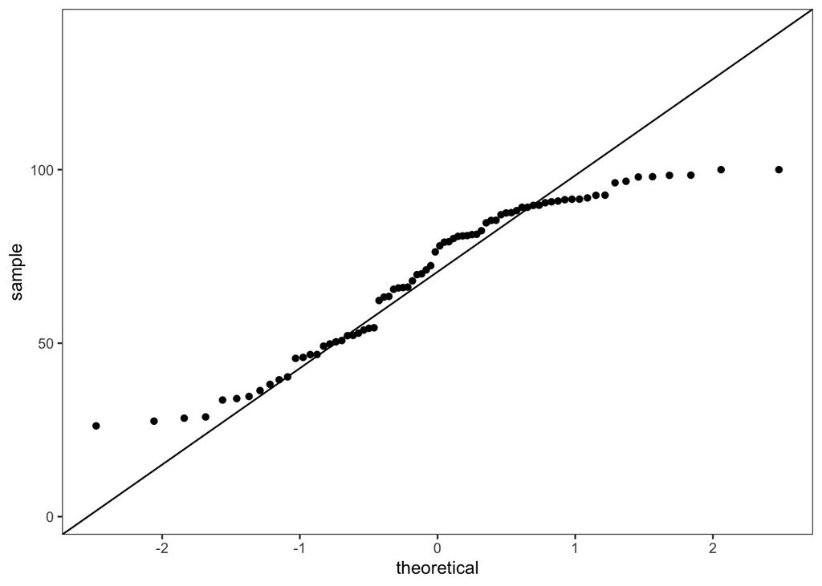

```r
strain_perc_OD_DF <- percentODDF %>%
  spread(measure, value) %>%
  select(-`Biofilm OD`, -`Planktonic OD`) %>%
  dplyr::rename(percentOD=`Percent OD`) %>%
  with_groups(c(Sample, Species, Strain, Batch, BioRep), summarize, mPercentOD=mean(percentOD), sdPercentOD=sd(percentOD)) %>%
  select(Sample, Strain, Species, mPercentOD, sdPercentOD)

#save formatted percent OD data
# write_csv(strain_perc_OD_DF, file.path(formattedPhenDataOut, "percent_biofilm_od.csv"))

#save formatted biofilm and planktonic OD data
# percentODDF %>%
#   spread(measure, value) %>%
#   select(-`Percent OD`) %>%
#   dplyr::rename(biofilmOD=`Biofilm OD`,
#                 planktonicOD=`Planktonic OD`) %>%
#   with_groups(c(Sample, Species, Strain, Batch, BioRep), summarize, mBiofilmOD=mean(biofilmOD), sdBiofilmOD=sd(biofilmOD), mPlanktonicOD=mean(planktonicOD), sdPlanktonicOD=sd(planktonicOD)) %>%
#   select(Sample, Strain, Species, mBiofilmOD, sdBiofilmOD, mPlanktonicOD, sdPlanktonicOD) %>%
#   write_csv(file.path(formattedPhenDataOut, "biofilm_and_planktonic_od.csv"))

strain_perc_OD_DF %>%
  ggplot(aes(sample=mPercentOD)) +
  geom_qq_line() +
  geom_qq()
```

#### One-way ANOVA

```r
strain_perc_OD_DF %>%
  anova_test(mPercentOD~Strain) %>%
  formattable
```

Effect

DFn

DFd

F

p

p<.05

ges

Strain

20

55

5.49

2.6e-07

0.666

#### Tukey’s HSD

```r
ODPostHoc <- strain_perc_OD_DF %>%
  tukey_hsd(mPercentOD~Strain, p.adjust.method = "BH")

#save posthoc test results in supplementary tables file
# suppl_xlsx <- loadWorkbook(suppTableOut)
# addWorksheet(suppl_xlsx, "TableS5_percent_od_posthoc")
#
# ODPostHoc %>%
#  arrange(p.adj) %>%
#  writeData(suppl_xlsx, x=.,  sheet="TableS5_percent_od_posthoc")
#
# saveWorkbook(suppl_xlsx, suppTableOut, overwrite = TRUE)
```

Plot pairwise post-hoc results

```r
pvals <- ODPostHoc %>%
  select(group1, group2, p.adj) %>%
  dplyr::rename(var1=group2, var2=group1, cor=p.adj) %>%
  cor_spread() %>%
  column_to_rownames(var="rowname") %>%
  as.matrix()

ODPostHoc %>%
  select(group1, group2, estimate) %>%
  dplyr::rename(var1=group2, var2=group1, cor=estimate) %>%
  cor_spread() %>%
  column_to_rownames(var="rowname") %>%
  as.matrix() %>%
  corrplot(is.corr=FALSE, type = "lower", tl.col="black", p.mat = pvals, insig = "label_sig", sig.level = c(0.001, 0.01, 0.05), pch.cex = 0.9)
```

```r
grid.echo()
```

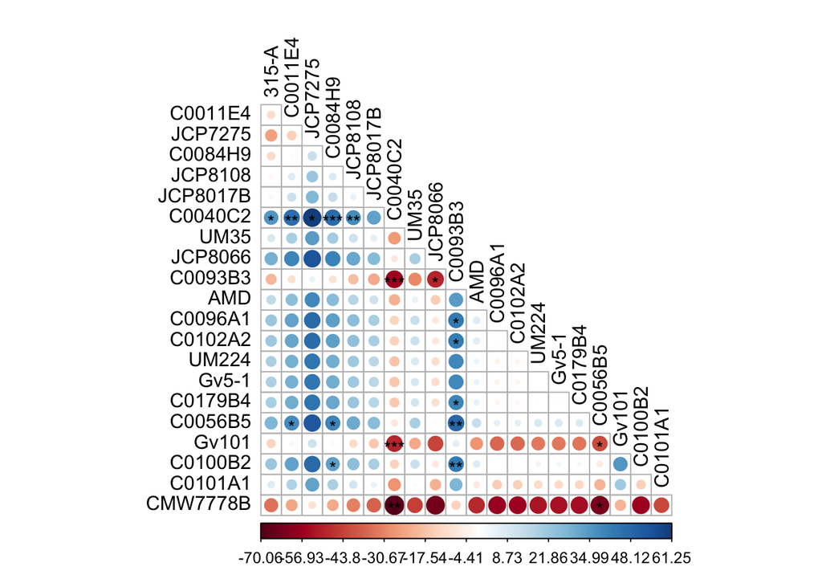

```r
percODPostHocPlot <- grid.grab()
```

Percent biofilm of Strains

```r
strain_perc_OD_DF %>%
  with_groups(Strain, summarize, `Percent OD Biofilm`=mean(mPercentOD)) %>%
  arrange(-`Percent OD Biofilm`) %>%
  formattable()
```

| Strain | Percent OD Biofilm |
| --- | --- |
| C0040C2 | 97.58907 |
| JCP8066 | 91.16070 |
| C0056B5 | 90.17673 |
| C0096A1 | 84.37130 |
| C0100B2 | 84.26520 |
| C0102A2 | 83.82580 |
| C0179B4 | 81.63978 |
| Gv5-1 | 80.78987 |
| UM224 | 80.75329 |
| AMD | 76.27148 |
| UM35 | 70.98144 |
| C0101A1 | 69.57704 |
| JCP8017B | 64.14116 |
| 315-A | 61.51312 |
| JCP8108 | 59.02140 |
| C0011E4 | 51.01499 |
| C0084H9 | 50.11188 |
| Gv101 | 48.29067 |
| C0093B3 | 41.46202 |
| JCP7275 | 36.34031 |
| CMW7778B | 27.52904 |

Average of all strains

```r
strain_perc_OD_DF %>%
  summarize(`Average Percent OD Biofilm`=mean(mPercentOD)) %>%
  formattable()
```

| Average Percent OD Biofilm |
| --- |
| 70.12149 |

# Safranin

```r
safPlankODDF <- rawSafPlanktonicODs %>%
  group_by(Batch) %>%
  mutate(safPlanktonicOD=OD-mean(.$OD[.$Number=="Blank"]),
                      OD=case_when(OD>0~OD,
                               OD<=0~0)) %>%
  filter(Number!="Blank") %>%
  ungroup %>%
  mutate(row=str_extract(well, pattern="[A-H]")) %>%
  select(-OD, -Measure, -well)

safSafODDF <- rawSafBiofilmODs %>%
  group_by(Batch) %>%
  mutate(safraninOD=OD-mean(.$OD[.$Number=="Blank"]),
                      OD=case_when(OD>0~OD,
                               OD<=0~0)) %>%
  filter(Number!="Blank") %>%
  ungroup %>%
  mutate(row=str_extract(well, pattern="[A-H]")) %>%
  select(-OD, -Measure, -well)


safraninOD1 <- safPlankODDF %>%
  full_join(safSafODDF) %>%
  select(row, everything(), safPlanktonicOD, safraninOD) %>%
  mutate(Sample=paste(Strain, Batch, BioRep, sep=".")) %>%
  filter(Sample %!in% midLogFail) %>% # quality filter for poor growth at mid log phase
  mutate(edgeWell=str_detect(row, pattern="[A|H]"),
         edgeWell=factor(edgeWell, levels=c(TRUE, FALSE)),
         innerWell=str_detect(row, pattern="[D|E]"),
         innerWell=factor(innerWell, levels=c(TRUE, FALSE)),
         topWell=str_detect(row, pattern="A"),
         topWell=factor(topWell, levels=c(TRUE, FALSE)))
head(safraninOD1)
```

```
## # A tibble: 6 × 13
##   row   Number BioRep Strain  Species  Protocol Batch safPlanktonicOD safraninOD
##   <chr> <chr>  <chr>  <chr>   <chr>       <dbl> <chr>           <dbl>      <dbl>
## 1 A     1      A      C0011E4 Gardner…        1 1A1             0.151      0.202
## 2 B     1      A      C0011E4 Gardner…        1 1A1             0.142      0.217
## 3 C     1      A      C0011E4 Gardner…        1 1A1             0.136      0.232
## 4 D     1      A      C0011E4 Gardner…        1 1A1             0.159      0.201
## 5 E     1      B      C0011E4 Gardner…        1 1A1             0.152      0.179
## 6 F     1      B      C0011E4 Gardner…        1 1A1             0.116      0.103
## # ℹ 4 more variables: Sample <chr>, edgeWell <fct>, innerWell <fct>,
## #   topWell <fct>
```

Organize data and create dataframe

```r
safDF <- safraninOD1 %>%
  mutate(Strain=factor(Strain, levels = strains),
         Species=factor(Species, levels = species),
         Protocol=as.character(Protocol),
         BatchNum=str_extract(Batch, "(?<=[A|B])[0-9]"),
         BatchRep=paste(BatchNum, BioRep, sep="."),
         method="Safranin Stain")  %>%
  filter(Sample %!in% naSamples) # remove samples with no growth
```

Check if edge wells should be removed

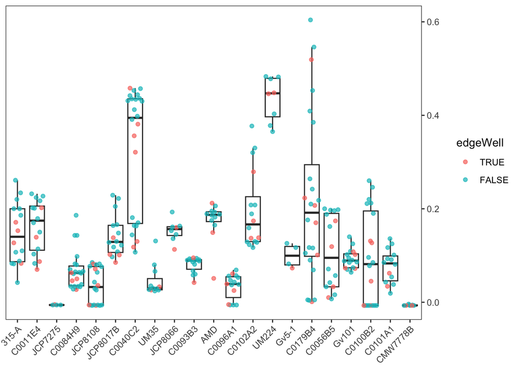

```r
safDF %>%
  ggplot(aes(x=Strain, y=safraninOD)) +
    geom_boxplot(alpha=0) +
    geom_quasirandom(aes(color=edgeWell), alpha=0.7) +
    scale_y_continuous(position = "right") +
    theme(axis.text.x = element_text(angle=45, hjust=1)) +
    labs(x=NULL, y=NULL, shape="Biological Replicate")
```

Do not remove edge wells ## Extra biological replicates

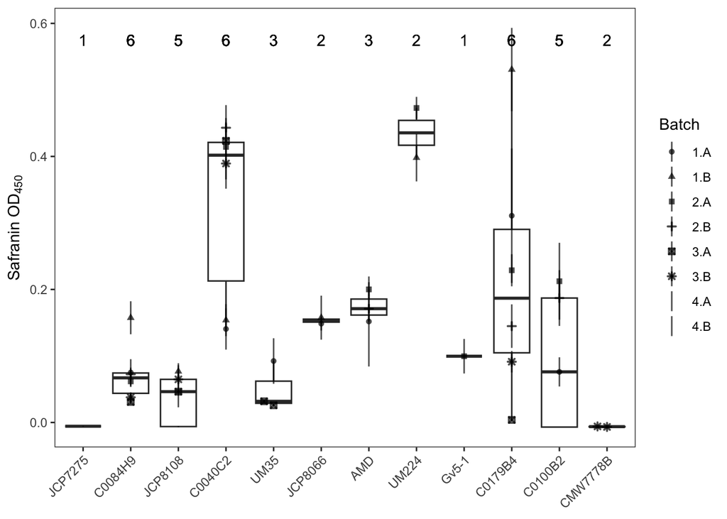

```r
non4StrainsSaf <- safDF %>%
 mutate(Sample=paste(Number, Sample, sep=".")) %>%
 with_groups(Strain, summarize, n=n_distinct(Sample)) %>%
 filter(n!=4) %>%
 .$Strain

safDF %>%
  filter(Strain %in% non4StrainsSaf) %>%
  mutate(Sample=paste(Number, Sample, sep=".")) %>%
  with_groups(Strain, mutate, n=n_distinct(Sample)) %>%
  with_groups(c("Number", "Strain", "Species", "Protocol", "Batch", "method", "Sample", "BatchRep", "BatchNum", "n"), summarize, safraninM=mean(safraninOD), safraninSD=sd(safraninOD)) %>%
  ggplot() +
  geom_boxplot(aes(x=Strain, y=safraninM), alpha=0) +
  geom_pointrange(aes(x=Strain, y=safraninM, ymin=safraninM-safraninSD, ymax=safraninM+safraninSD, shape=BatchRep), alpha=0.7, position=position_quasirandom(), size=0.3) +
  geom_text(aes(x=Strain, y=0.575, label=n)) +
  theme(axis.text.x = element_text(angle=45, hjust=1)) +
  labs(x=NULL, y=bquote("Safranin OD"[450]), shape="Batch")
```

## Plot

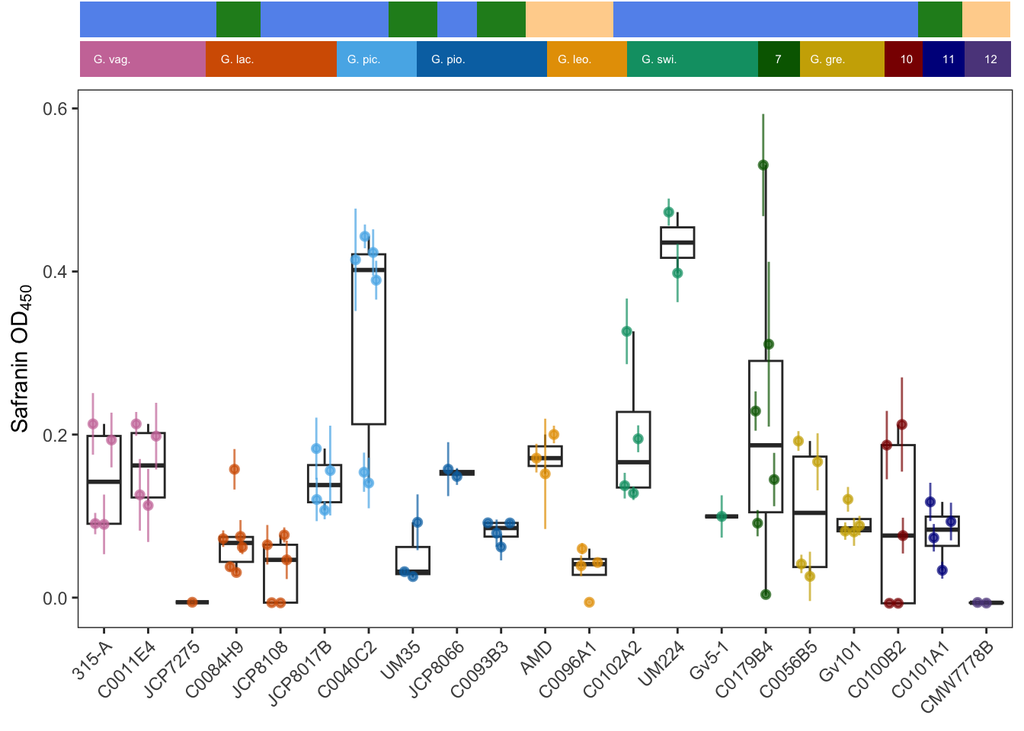

```r
safPlot <- safDF %>%
  ggplot(aes(x=Strain, y=safraninOD, color=Species, shape=BatchRep)) +
  geom_quasirandom(alpha=0.75) +
  theme(axis.text.x = element_text(angle=45, hjust=1)) +
  labs(x=NULL, y=bquote("Safranin OD"[450]), shape="Biological Replicate")

safPlot2 <- safDF %>%
  with_groups(c("Number", "Strain", "Species", "Protocol", "Batch", "method", "Sample", "BatchRep", "BatchNum"), summarize, safraninM=mean(safraninOD), safraninSD=sd(safraninOD)) %>%
  ggplot() +
  geom_boxplot(aes(x=Strain, y=safraninM), alpha=0) +
  geom_pointrange(aes(x=Strain, y=safraninM, ymin=safraninM-safraninSD, ymax=safraninM+safraninSD, color=Species), alpha=0.7, position=position_quasirandom(), size=0.3) +
  speciesColor +
  theme(axis.text.x = element_text(angle=45, hjust=1),
        legend.position = "none") +
  labs(x=NULL, y=bquote("Safranin OD"[450]), shape="Batch")

safPlots <- plot_grid(protocolBar0, speciesBar0, safPlot2, ncol = 1, rel_heights = c(0.06, 0.06, 1), align = "v", axis = "lr")

safPlots
```

## Compare Safranin

### Isolate ANOVA

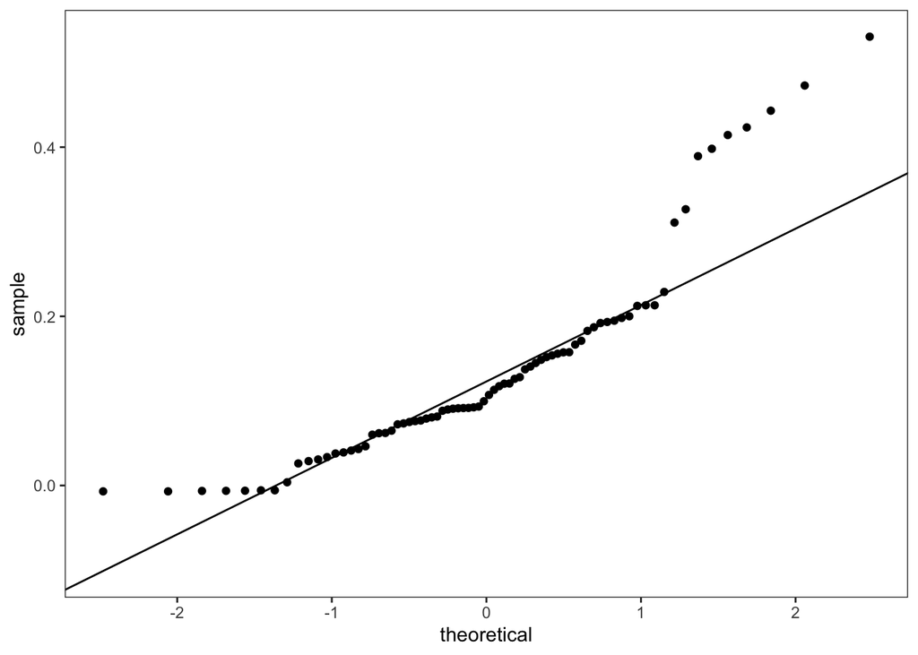

```r
safDF %>%
  with_groups(c(Sample, Species, Strain, Batch, BioRep), summarize, mSafOD=mean(safraninOD), sdSafOD=sd(safraninOD)) %>%
  ggplot(aes(sample=mSafOD)) +
  geom_qq_line() +
  geom_qq()
```

#### One-way ANOVA

```r
strain_saf_DF <- safDF %>%
  with_groups(c(Sample, Species, Strain, Batch, BioRep), summarize, mSafOD=mean(safraninOD), sdSafOD=sd(safraninOD)) %>%
  select(Sample, Strain, Species, mSafOD, sdSafOD)

# save formatted data
#write_csv(strain_saf_DF, file.path(formattedPhenDataOut, "safranin_od.csv"))

strain_saf_DF %>%
  anova_test(mSafOD~Strain) %>%
  formattable
```

Effect

DFn

DFd

F

p

p<.05

ges

Strain

20

55

4.469

5.31e-06

0.619

#### Tukey’s HSD

```r
safPostHoc <- strain_saf_DF %>%
  tukey_hsd(mSafOD~Strain, p.adjust.method = "BH")

#save posthoc test results in supplementary tables file
# suppl_xlsx <- loadWorkbook(suppTableOut)
# addWorksheet(suppl_xlsx, "TableS6_safranin_posthoc")
#
# safPostHoc %>%
#  arrange(p.adj) %>%
#  writeData(suppl_xlsx, x=.,  sheet="TableS6_safranin_posthoc")
#
# saveWorkbook(suppl_xlsx, suppTableOut, overwrite = TRUE)
```

Plot pairwise post-hoc results

```r
pvals <- safPostHoc %>%
  select(group1, group2, p.adj) %>%
  dplyr::rename(var1=group2, var2=group1, cor=p.adj) %>%
  cor_spread() %>%
  column_to_rownames(var="rowname") %>%
  as.matrix()

safPostHoc %>%
  select(group1, group2, estimate) %>%
  dplyr::rename(var1=group2, var2=group1, cor=estimate) %>%
  cor_spread() %>%
  column_to_rownames(var="rowname") %>%
  as.matrix() %>%
  corrplot(is.corr=FALSE, type = "lower", tl.col="black", p.mat = pvals, insig = "label_sig", sig.level = c(0.001, 0.01, 0.05), pch.cex = 0.9)
```

```r
grid.echo()
```

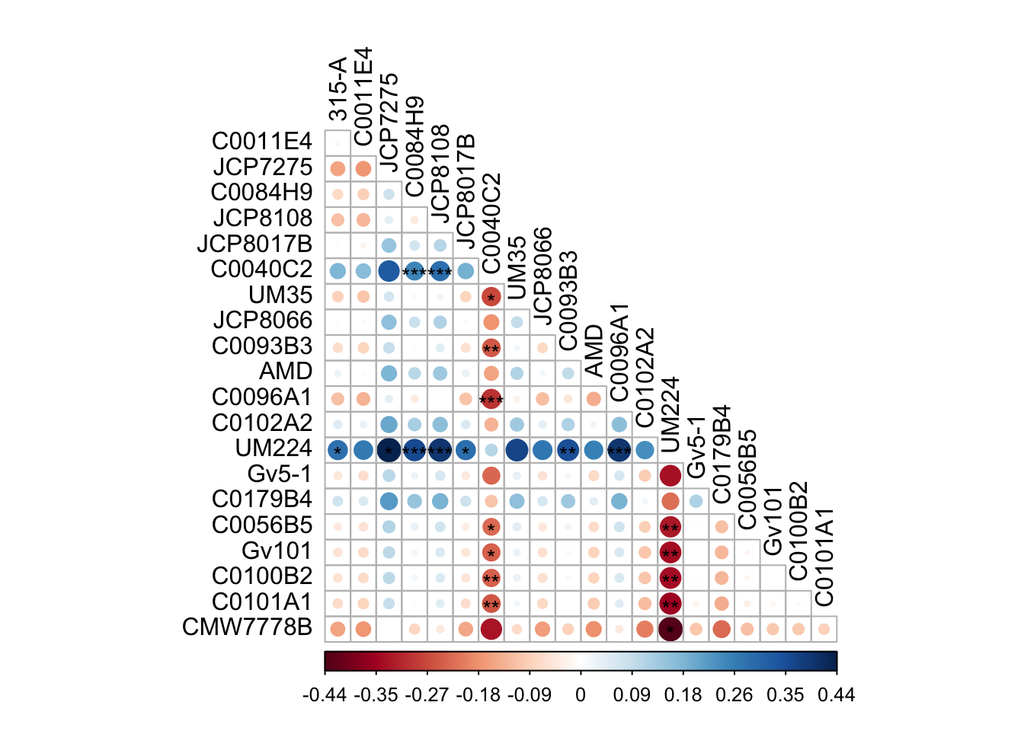

```r
safraninPostHocPlot <- grid.grab()
```

# Figure 4: Biofilm growth as percent OD and Safranin stain

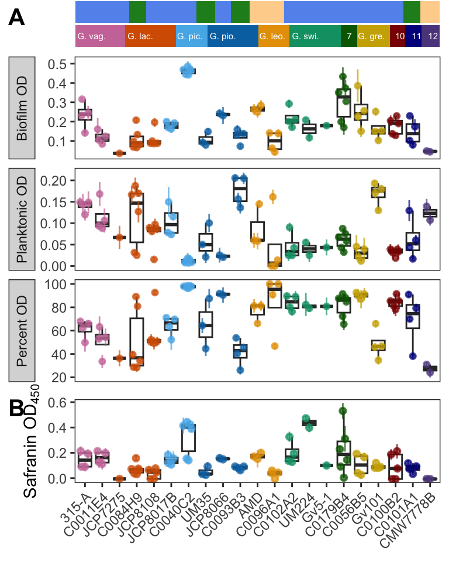

```r
plot_grid(protocolBar0, speciesBar0, percentODPlot + speciesColor + theme(axis.text.x = element_blank(), axis.ticks.x = element_blank()), safPlot2, ncol = 1, rel_heights = c(0.07, 0.07, 1, 0.5), align = "v", axis = "lr", labels = c("A", "", "", "B"), label_size = 15)
```

```r
#ggsave(file.path(figureOut, paste(Sys.Date(), "Figure4_strain_biofilm.png", sep="_")))
```

# Figure S3: Post Hoc Test Results

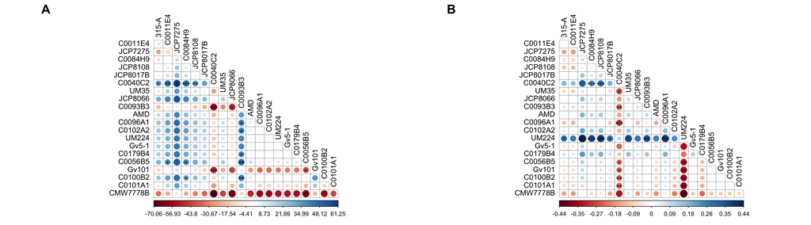

```r
#fig.width=7.5, fig.height=10
plot_grid(ggplot()+geom_blank(), percODPostHocPlot, ggplot()+geom_blank(), safraninPostHocPlot, nrow = 1, rel_widths = c(0.1, 1, 0.1, 1), labels = c(" ", "A", " ", "B"), label_size = 20)
```

```r
#plot_grid(percODPostHocPlot, ggplot()+geom_blank()+theme_void(), safraninPostHocPlot, nrow = 3, rel_heights = c(1, 0.3, 1), labels = c("A", " ","B"), label_size = 20)
#ggsave(file.path(figureOut, paste(Sys.Date(), "FigureS3_biofilm_posthocs.png", sep = "_")))
```